# Titanic

Beto

May 13, 2017

## Titanic: Machine Learning from Disaster

#### Competition Description

The sinking of the RMS Titanic is one of the most infamous shipwrecks in history. On April 15, 1912, during her maiden voyage, the Titanic sank after colliding with an iceberg, killing 1502 out of 2224 passengers and crew.

This sensational tragedy shocked the international community and led to better safety regulations for ships.

One of the reasons that the shipwreck led to such loss of life was that there were not enough lifeboats for the passengers and crew.

Although there was some element of luck involved in surviving the sinking, some groups of people were more likely to survive than others, such as women, children, and the upper-class.

In this challenge, we ask you to complete the analysis of what sorts of people were likely to survive. In particular, we ask you to apply the tools of machine learning to predict which passengers survived the tragedy.

Practice Skills

- Binary classification
- Python and R basics

Overview The data has been split into two groups:

- training set (train.csv)
- test set (test.csv)

The training set should be used to build your machine learning models. For the training set, we provide the outcome (also known as the “ground truth”) for each passenger. Your model will be based on “features” like passengers’ gender and class. You can also use feature engineering to create new features.

The test set should be used to see how well your model performs on unseen data. For the test set, we do not provide the ground truth for each passenger. It is your job to predict these outcomes. For each passenger in the test set, use the model you trained to predict whether or not they survived the sinking of the Titanic.

#### Data Dictionary

| Variable | Definition | Key |
| --- | --- | --- |
| survival | Survival | 0 = No, 1 = Yes |
| pclass | Ticket class | 1 = 1st, 2 = 2nd, 3 = 3rd |
| sex | Sex |  |
| Age | Age in years |  |
| sibsp | nr. of siblings / spouses aboard the Titanic |  |
| parch | # of parents / children aboard the Titanic |  |
| ticket | Ticket number |  |
| fare | Passenger fare |  |
| cabin | Cabin number |  |
| embarked | Port of Embarkation | C = Cherbourg, Q = Queenstown, S = Southampton |

#### Variable Notes

pclass: A proxy for socio-economic status (SES)

- 1st = Upper
- 2nd = Middle
- 3rd = Lower

age: Age is fractional if less than 1. If the age is estimated, is it in the form of xx.5

sibsp: The dataset defines family relations in this way…

- Sibling = brother, sister, stepbrother, stepsister
- Spouse = husband, wife (mistresses and fiancés were ignored)

parch: The dataset defines family relations in this way…

- Parent = mother, father
- Child = daughter, son, stepdaughter, stepson
- Some children travelled only with a nanny, therefore parch=0 for them.

#### Importing the data downloaded from kaggle competition

```r
library(tidyverse)
# Import train dataset
train <- read_csv("~/Data Science/kaggle/titanic/train.csv",
                  col_types =
                    cols(Embarked = col_factor(levels = c("C","Q","S")),
                         Pclass = col_factor(levels = c("1","2", "3")),
                         Sex = col_factor(levels = c("male","female")),
                         Survived = col_factor(levels = c("0","1"))))
train <- as.data.frame(train)

# Import test dataset
test <- read_csv("~/Data Science/kaggle/titanic/test.csv",
                 col_types =
                   cols(Embarked = col_factor(levels = c("C","Q","S")),
                        Pclass = col_factor(levels = c("1","2", "3")),
                        Sex = col_factor(levels = c("male","female"))))
test <- as.data.frame(test)
```

First we need to know the data in both datasets.

```r
head(train)    # viewing the first 6 lines
```

```
##   PassengerId Survived Pclass
## 1           1        0      3
## 2           2        1      1
## 3           3        1      3
## 4           4        1      1
## 5           5        0      3
## 6           6        0      3
##                                                  Name    Sex Age SibSp
## 1                             Braund, Mr. Owen Harris   male  22     1
## 2 Cumings, Mrs. John Bradley (Florence Briggs Thayer) female  38     1
## 3                              Heikkinen, Miss. Laina female  26     0
## 4        Futrelle, Mrs. Jacques Heath (Lily May Peel) female  35     1
## 5                            Allen, Mr. William Henry   male  35     0
## 6                                    Moran, Mr. James   male  NA     0
##   Parch           Ticket    Fare Cabin Embarked
## 1     0        A/5 21171  7.2500  <NA>        S
## 2     0         PC 17599 71.2833   C85        C
## 3     0 STON/O2. 3101282  7.9250  <NA>        S
## 4     0           113803 53.1000  C123        S
## 5     0           373450  8.0500  <NA>        S
## 6     0           330877  8.4583  <NA>        Q
```

```r
str(train)     # structure of data
```

[output not shown]

```r
summary(train) # main statistics
```

```
##   PassengerId    Survived Pclass      Name               Sex
##  Min.   :  1.0   0:549    1:216   Length:891         male  :577
##  1st Qu.:223.5   1:342    2:184   Class :character   female:314
##  Median :446.0            3:491   Mode  :character
##  Mean   :446.0
##  3rd Qu.:668.5
##  Max.   :891.0
##
##       Age            SibSp           Parch           Ticket
##  Min.   : 0.42   Min.   :0.000   Min.   :0.0000   Length:891
##  1st Qu.:20.12   1st Qu.:0.000   1st Qu.:0.0000   Class :character
##  Median :28.00   Median :0.000   Median :0.0000   Mode  :character
##  Mean   :29.70   Mean   :0.523   Mean   :0.3816
##  3rd Qu.:38.00   3rd Qu.:1.000   3rd Qu.:0.0000
##  Max.   :80.00   Max.   :8.000   Max.   :6.0000
##  NA's   :177
##       Fare           Cabin           Embarked
##  Min.   :  0.00   Length:891         C   :168
##  1st Qu.:  7.91   Class :character   Q   : 77
##  Median : 14.45   Mode  :character   S   :644
##  Mean   : 32.20                      NA's:  2
##  3rd Qu.: 31.00
##  Max.   :512.33
##
```

### Train dataset

It has 891 lines (observations) by 12 coluns (variables)

[output not shown]

The objective of this challenge is to predict whether or not a passanger of Titanic survived or not, given several variables of each one.

So, how many passangers survived? First construct a table and find the proportions

```r
# table
table(train$Survived)
```

```
##
##   0   1
## 549 342
```

```r
# proportions
prop.table(table(train$Survived))
```

```
##
##         0         1
## 0.6161616 0.3838384
```

We can see that in our dataset **549 passangers or 61% didn’t survived** and **342 or 38% did survived**.

It would also be helpful to see a two-way table comparing survived with another variable to see if it may have predictive value. For example:

```r
# absolute numbers
table(train$Pclass, train$Survived)
```

```
##
##       0   1
##   1  80 136
##   2  97  87
##   3 372 119
```

```r
# proportions
prop.table(table(train$Pclass, train$Survived), margin = 1)
```

```
##
##             0         1
##   1 0.3703704 0.6296296
##   2 0.5271739 0.4728261
##   3 0.7576375 0.2423625
```

```r
table(train$Sex, train$Survived)
```

```
##
##            0   1
##   male   468 109
##   female  81 233
```

```r
prop.table(table(train$Sex, train$Survived), margin = 1)
```

```
##
##                  0         1
##   male   0.8110919 0.1889081
##   female 0.2579618 0.7420382
```

Similarly with gender, 468 or 81% of male died and just 109 or 19% survived.

What about the port of embarkment?

```r
table(train$Embarked, train$Survived)
```

```
##
##       0   1
##   C  75  93
##   Q  47  30
##   S 427 217
```

```r
round(prop.table(table(train$Embarked, train$Survived), margin = 1),2)
```

```
##
##        0    1
##   C 0.45 0.55
##   Q 0.61 0.39
##   S 0.66 0.34
```

Note there is decrement in survived (=1) from Cherbourg (France), Queenstown (now Cobh) in Ireland , up to Southampton (England).

It’s there a relation with port of embarkment and class?

```r
table(train$Embarked, train$Pclass)
```

```
##
##       1   2   3
##   C  85  17  66
##   Q   2   3  72
##   S 127 164 353
```

```r
round(prop.table(table(train$Embarked, train$Pclass), margin = 1),2)
```

```
##
##        1    2    3
##   C 0.51 0.10 0.39
##   Q 0.03 0.04 0.94
##   S 0.20 0.25 0.55
```

From table and proportions we can see the following facts:

- Passangers embarked at Cherbourg (France) were 61% on both 1st. and 2nd. class and that could explain that these kind of passangers survived the most
- On the contrary, 94% passangers embarked at Queenstown (now Cobh) in Ireland were at the 3rd. class, meaning that there were poor inmigrants.
- At Southampton (England) embarked most of passangers, being 45% between 1st. and 2nd. class and 55% on the 3rd.

#### Visualization

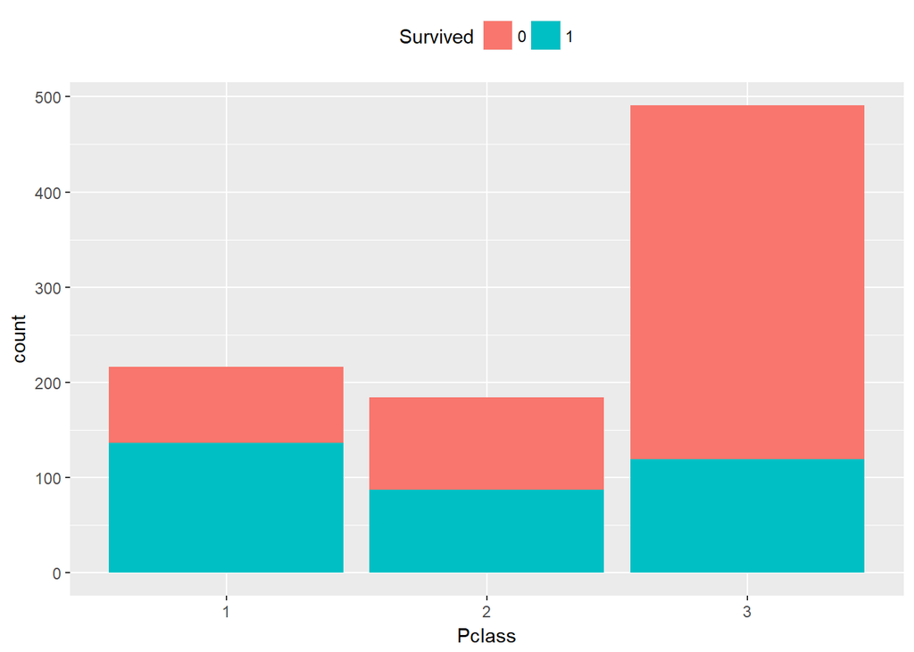

```r
library(ggplot2)
#
qplot(Pclass, data=train, geom="bar", fill = Survived) +
theme(legend.position = "top")
```

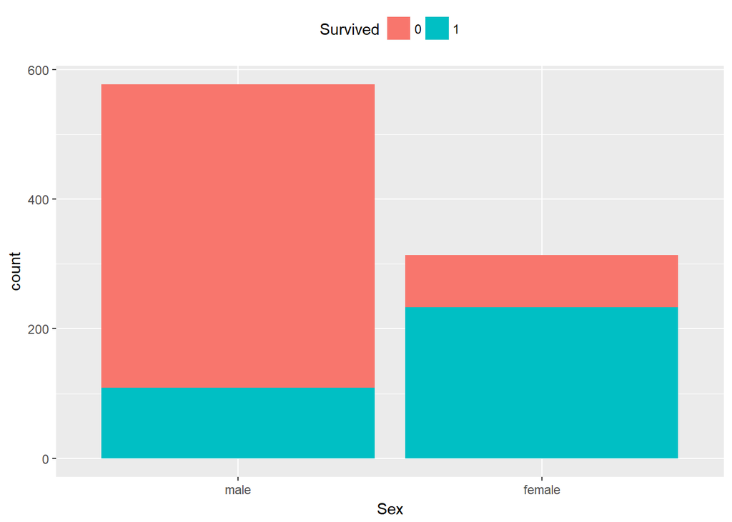

```r
qplot(Sex, data=train, geom="bar", fill= Survived) +
theme(legend.position = "top")
```

An insteresting investigation could be made on childs. We can expect that if a passenger is a child, there is more chance to survived. Considering a child a person with less than 16 years (?), let’s see the numbers…

```r
# criating a vector with the row where the passenger have less than 16 y.o.
child <- which(train$Age < 16)
# subsetting the train data set
child_status <- subset(train[child,])
# how many survived?
summary(child_status$Survived)
```

```
##  0  1
## 34 49
```

```r
# let's see by Pclass
# table with survived status by Pclass
table(child_status$Pclass, child_status$Survived)
```

```
##
##      0  1
##   1  1  5
##   2  0 19
##   3 33 25
```

```r
# proportions
prop.table(table(child_status$Pclass, child_status$Survived), margin = 1)
```

```
##
##             0         1
##   1 0.1666667 0.8333333
##   2 0.0000000 1.0000000
##   3 0.5689655 0.4310345
```

So be a child from the second or first class was a passport to survived and that characteristic has to be considered when the analysis of the final train data set would be made

```r
# setting the NA for Age and Fare
train$Age[is.na(train$Age)] <- 999
train$Embarked[is.na(train$Embarked)] <- "S"
train = mutate(train, chilhood = ifelse (Age < 14,1,0))

test$Age[is.na(test$Age)] <- 999
test$Fare[is.na(test$Fare)] <- 0
test <- mutate(test, chilhood =  ifelse (Age < 14,1,0))
```

Load the randomForest library, set seed and calculate de random forest classifier

```r
library(randomForest)
# Set seed and create a random forest classifier
set.seed(1234)
model_forest <- randomForest(Survived ~ Pclass +
                               Sex + Fare +
                               chilhood +
                               Embarked +
                               SibSp +
                               Parch,
                             data = train,
                             importance = TRUE,
                             ntree = 100,
                             nodesize = 1,
                             na.action=na.exclude)
```

```r
# predict the values in train dataset
pred_forest_train <- predict(model_forest, train)
# Observe the first few rows of your predictions
head(pred_forest_train)
```

```
## 1 2 3 4 5 6
## 0 1 0 1 0 0
## Levels: 0 1
```

#### Evaluating the Random Forest

access your first random forest with model_forest and predictions as pred_forest_train.

Use the library caret to view the confusion matrix for the model.

This will tell you the model’s accuracy on the training set as well as other performance measures like sensitivity and specificity.

You can see this by running the following code:

```r
library(caret)
confusionMatrix(pred_forest_train, train$Survived)
```

```
## Confusion Matrix and Statistics
##
##           Reference
## Prediction   0   1
##          0 522  85
##          1  27 257
##
##                Accuracy : 0.8743
##                  95% CI : (0.8507, 0.8954)
##     No Information Rate : 0.6162
##     P-Value [Acc > NIR] : < 2.2e-16
##
##                   Kappa : 0.7255
##  Mcnemar's Test P-Value : 7.205e-08
##
##             Sensitivity : 0.9508
##             Specificity : 0.7515
##          Pos Pred Value : 0.8600
##          Neg Pred Value : 0.9049
##              Prevalence : 0.6162
##          Detection Rate : 0.5859
##    Detection Prevalence : 0.6813
##       Balanced Accuracy : 0.8511
##
##        'Positive' Class : 0
##
```

```r
# Variable Importance
# Now it is time to take a look at how important the inputs were
# to your predictive model. Here, you can use:
importance(model_forest)
```

```
##                  0         1 MeanDecreaseAccuracy MeanDecreaseGini
## Pclass   10.051915 12.262163            16.901833         31.07485
## Sex      26.327960 36.226742            36.033039        103.61238
## Fare      9.995989  8.957510            15.169699         60.25687
## chilhood 11.832830 14.933966            16.627085         13.55012
## Embarked  3.533399  5.004537             6.733161         10.49657
## SibSp    10.777620  1.604072            10.957807         16.22293
## Parch     5.813538  3.115798             6.728737         11.90003
```

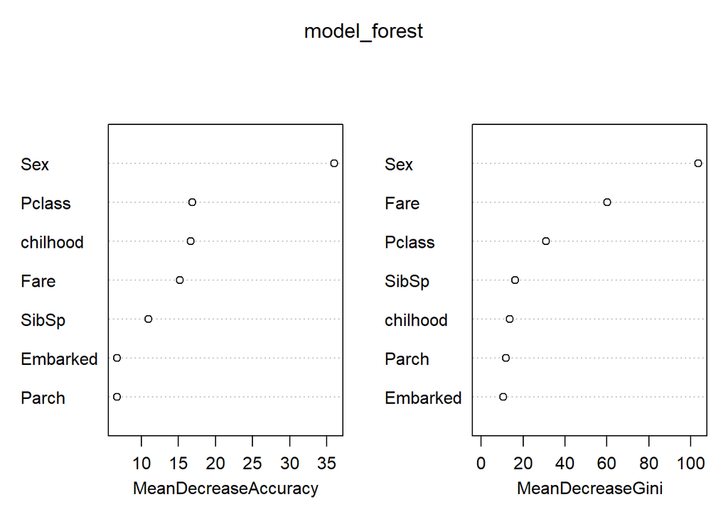

```r
varImpPlot(model_forest)
```

Create the submission file

```r
# Predict using the test values
pred_forest_test <- predict(model_forest, test)

# Create submission data frame
submission <- data.frame(test$PassengerId)
submission$Survived <- pred_forest_test
names(submission)[1] <- "PassengerId"
write.csv(submission,
          file = "submission.csv",
          row.names = F,
          quote = F)
#END
```

```r
Sys.time()
```

```
## [1] "2017-05-30 17:31:36 -03"
```